# Replication Assignment

## The Customer Isn’t Always Right— Conservation and Animal Welfare Implications of the Increasing Demand for Wildlife Tourism

### Moorhouse *et al.* (2015)

### Introduction

This study focuses on the diversity of Wildlife Tourist Attractions (WTAs) across the globe and how they impact the conservation and welfare of the animals involved. They also aimed to understand tourists’ perceptions of WTAs through an objective assessment of their impacts to focus on areas where tourist education may be helpful. Overall, this paper presents an examination of non-consumptive (no fishing/hunting), & non-zoo WTAs worldwide that fall into 5 categories: “Captive Interactions”, “Sanctuary attractions”, “Farmed Wildlife”, “Street Performances”, and “Wild attractions”. In each category, they assigned a conservation and welfare score (+1 to +3 for positive impacts, -1 to -3 for negative impacts, and 0 for no impact) based on a number of criteria such as, direct conservation benefits the WTA provides to the species and if the WTA fulfulls the 5 animal welfare freedoms (see Fig 1 and 2 below). They also analyzed the feedback reviews from tourists on TripAdvisor. Ultimatley, they compared the tourist reviews with the corresponding conservation and welfare scores in order to examine tourists’ assessments of various WTAs.

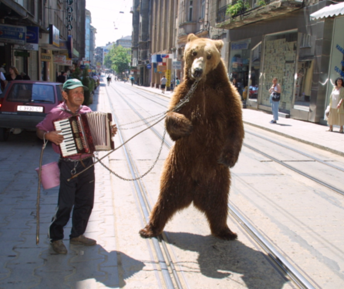

**Bear Dancing**

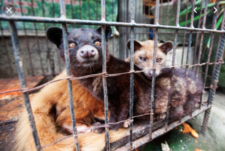

**Civet Coffee Farm**

[figure not shown]

**Tiger Cub Encounter**

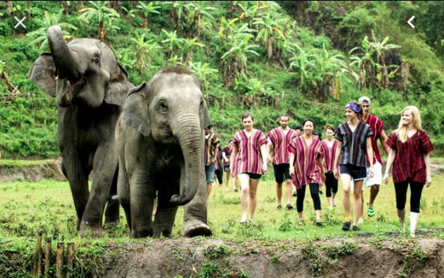

**Elephant Sanctuary**

```r
> library(curl)
> library(ggplot2)
```

### Importing my data!

```r
> WTA_reviews<- curl("https://raw.githubusercontent.com/langley1/AN597_Replication_Assignment/master/WTA_Reviews.csv") # I saved their original excel datasheet as a csv, uploaded to my repo, and am pulling it in here using curl
> WTA_reviews<- read.csv(WTA_reviews, header = T, sep = ",")
> head(WTA_reviews)
```

```
##   Search.term              Type Category      Country
## 1        Bear         Bear park  Captive        Japan
## 2        Bear         Bear park  Captive        Japan
## 3       Civet Civet coffee farm     Farm    Indonesia
## 4  Crocodile     Crocodile farm     Farm     Malaysia
## 5  Crocodile     Crocodile farm     Farm     Cambodia
## 6  Crocodile     Crocodile farm     Farm South Africa
##                 Attraction Date.rated Terrible Poor Average Very.Good
## 1     Bear Mountain Sahoro    10/9/14        0    1       3        16
## 2    Noboribetsu Bear Park    10/9/14        6    5      36        54
## 3 Luwak Civet Coffee Farm     9/22/14       14    3      16        34
## 4                      Zoo    12/3/14        7    3      17         2
## 5          Crocodile farm     12/3/14        9    9      19         4
## 6                     Farm    12/3/14        2    6      22        31
##   Excellent Total.reviews
```

[output cut: 27 more lines]

The original dataset has all of the subject taxa, the type/category of each WTA, and all of the reviews collected from Trip Advisor

### Conservation and Welfare Score Flowcharts

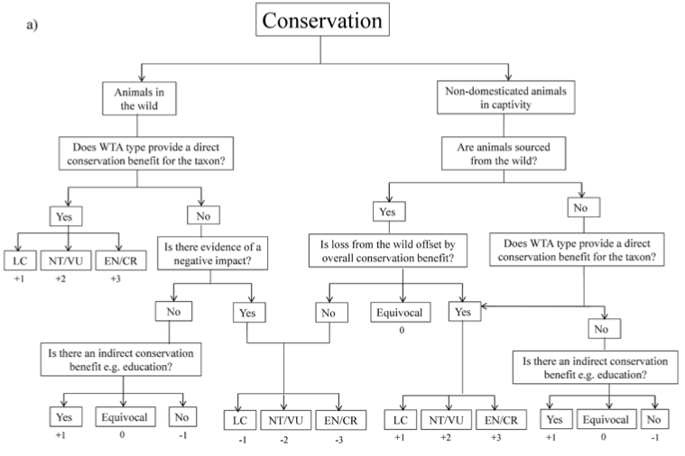

Fig 1. Conservation Scores

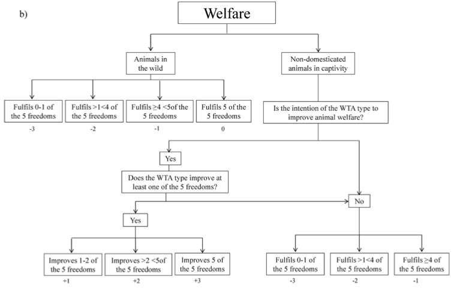

Fig 2. Welfare Scores

##### Let’s Get Replicating!

For this assignment, I will replicate **1)** finding the average tourist dissatisfaction score (DS) across all of the WTA types, **2)** an ANOVA to see if tourist dissatisfaction scores differed across the various subject taxa **3)** the Tukey Post Hoc to see which taxa differed in their dissatisfaction scores and **4)** Figure 3, which shows tourist dissatisfaction scores from TripAdvisor reviews (measured as the percentage of all positive and negative reviews that were negative).

### Replication 1

Finding the average tourist dissatisfaction score (DS) across the WTA types

```r
> DS_mean<- mean(WTA_reviews$Percentage, na.rm = T) #The "Percentage" column in the dataset is the tourist dissatisfaction scores measured as the percentage of all reviews (discounting ‘average’ reviews) accounted for by negative reviews (i.e. 100 x (negatives /(positives + negatives))), where a low percentage indicates that few tourists had a negative perception of the attraction
> DS_mean
```

```
## [1] 7.820213
```

```r
> DS_SD<- sd(WTA_reviews$Percentage, na.rm = T)
> DS_SD
```

```
## [1] 14.70466
```

**Report from Results Section**: “The mean tourist dissatisfaction score was 7.8% (SD 14.7) across all WTAs.”

> I get the same results for tourist DS mean and standard deviation in my analyses.

### Replication 2

Doing an ANOVA to see if tourist dissatisfaction scores differed across the various subject taxa

```r
> DS_score<- WTA_reviews$Percentage #creating a new object for the dissatisfaction score
> Taxa<- WTA_reviews$Search.term #creating a new object for the subject taxa
>
> Anova<- aov(DS_score~Taxa) #running the anova
> summary(Anova)
```

```
##              Df Sum Sq Mean Sq F value   Pr(>F)
## Taxa         10   8534   853.4   4.735 5.22e-06 ***
## Residuals   177  31900   180.2
## ---
## Signif. codes:  0 '***' 0.001 '**' 0.01 '*' 0.05 '.' 0.1 ' ' 1
```

**Report from Results Section**: “Tourist dissatisfaction scores varied between subject taxa (F(10,187) = 4.36, p < 0.001; Fig 3)”

> My F value is ever so slightly off (4.36 vs. 4.74). I’m not sure why they are coming out different. However, I still get a p value < 0.001, which shows the tourist dissatisfaction scores do vary significantly between subject taxa

### Replication 3

Running the Tukey Post Hoc Test to see which taxa differed significantly in their dissatisfaction scores

```r
> posthoc<- TukeyHSD(Anova, "Taxa", conf.level = 0.95)
> head(posthoc)
```

```
## $Taxa
##                             diff        lwr        upr        p adj
## Civet-Bear            18.5750000 -30.375850 67.5258499 9.772385e-01
## Crocodile -Bear       22.6607143  -2.161897 47.4833257 1.084624e-01
## Dolphin-Bear           1.1880435 -21.329039 23.7051260 1.000000e+00
## Elephant-Bear          9.9959677 -12.590658 32.5825936 9.355451e-01
## Gorilla-Bear          -1.4250000 -39.342165 36.4921653 1.000000e+00
## Lion-Bear              4.8750000 -21.027355 30.7773551 9.999375e-01
## Orangutan-Bear         4.5500000 -26.409236 35.5092358 9.999939e-01
## Shark-Bear            -1.2316667 -25.869721 23.4063875 1.000000e+00
## Tiger-Bear            14.9750000 -18.464797 48.4147966 9.305747e-01
## Turtle-Bear           18.5500000 -12.409236 49.5092358 6.806195e-01
## Crocodile -Civet       4.0857143 -41.233966 49.4053950 9.999999e-01
## Dolphin-Civet        -17.3869565 -61.486054 26.7121413 9.701512e-01
## Elephant-Civet        -8.5790323 -52.713680 35.5556150 9.999159e-01
## Gorilla-Civet        -20.0000000 -73.622969 33.6229694 9.799032e-01
## Lion-Civet           -13.7000000 -59.619968 32.2199676 9.964336e-01
## Orangutan-Civet      -14.0250000 -62.975850 34.9258499 9.974449e-01
## Shark-Civet          -19.8066667 -65.025525 25.4121915 9.396378e-01
## Tiger-Civet           -3.6000000 -54.156220 46.9562204 1.000000e+00
## Turtle-Civet          -0.0250000 -48.975850 48.9258499 1.000000e+00
## Dolphin-Crocodile    -21.4726708 -34.306484 -8.6388576 8.675065e-06
## Elephant-Crocodile   -12.6647465 -25.620186  0.2906934 6.162898e-02
## Gorilla-Crocodile    -24.0857143 -57.182530  9.0111010 3.898092e-01
## Lion-Crocodile       -17.7857143 -35.913587  0.3421580 5.964190e-02
## Orangutan-Crocodile  -18.1107143 -42.933326  6.7118972 3.858585e-01
## Shark-Crocodile      -23.8923810 -40.162644 -7.6221176 1.824895e-04
## Tiger-Crocodile       -7.6857143 -35.540835 20.1694065 9.981355e-01
## Turtle-Crocodile      -4.1107143 -28.933326 20.7118972 9.999811e-01
## Elephant-Dolphin       8.8079243   1.146306 16.4695421 1.061210e-02
## Gorilla-Dolphin       -2.6130435 -34.017759 28.7916719 1.000000e+00
## Lion-Dolphin           3.6869565 -11.127790 18.5017032 9.992293e-01
## Orangutan-Dolphin      3.3619565 -19.155126 25.8790390 9.999929e-01
## Shark-Dolphin         -2.4197101 -14.892819 10.0533983 9.999174e-01
## Tiger-Dolphin         13.7869565 -12.034831 39.6087442 8.119512e-01
## Turtle-Dolphin        17.3619565  -5.155126 39.8790390 3.033231e-01
## Gorilla-Elephant     -11.4209677 -42.875583 20.0336473 9.834918e-01
## Lion-Elephant         -5.1209677 -20.041202  9.7992662 9.891860e-01
## Orangutan-Elephant    -5.4459677 -28.032594 17.1406581 9.994156e-01
## Shark-Elephant       -11.2276344 -23.825852  1.3705836 1.294330e-01
## Tiger-Elephant         4.9790323 -20.903421 30.8614854 9.999235e-01
## Turtle-Elephant        8.5540323 -14.032594 31.1406581 9.775558e-01
## Lion-Gorilla           6.3000000 -27.614144 40.2141437 9.999446e-01
## Orangutan-Gorilla      5.9750000 -31.942165 43.8921653 9.999881e-01
## Shark-Gorilla          0.1933333 -32.765290 33.1519567 1.000000e+00
## Tiger-Gorilla         16.4000000 -23.568202 56.3682016 9.607245e-01
## Turtle-Gorilla        19.9750000 -17.942165 57.8921653 8.243764e-01
## Orangutan-Lion        -0.3250000 -26.227355 25.5773551 1.000000e+00
## Shark-Lion            -6.1066667 -23.980990 11.7676565 9.895607e-01
## Tiger-Lion            10.1000000 -18.721480 38.9214800 9.873364e-01
## Turtle-Lion           13.6750000 -12.227355 39.5773551 8.224202e-01
## Shark-Orangutan       -5.7816667 -30.419721 18.8563875 9.995397e-01
## Tiger-Orangutan       10.4250000 -23.014797 43.8647966 9.949089e-01
## Turtle-Orangutan      14.0000000 -16.959236 44.9592358 9.262323e-01
## Tiger-Shark           16.2066667 -11.484116 43.8974490 7.108144e-01
## Turtle-Shark          19.7816667  -4.856387 44.4197208 2.473878e-01
## Turtle-Tiger           3.5750000 -29.864797 37.0147966 9.999997e-01
```

**Report from Results Section**: "Tukey post-hoc tests for effects of subject taxon revealed that dolphins had significantly lower mean tourist dissatisfaction scores than crocodiles and elephants (T = 5.090, p < 0.001; T = 4.1062, p < 0.05, respectively) and that sharks had lower scores than crocodiles (T = 5.887, p < 0.001), all other comparisons being non-significant (T < 3.2, p > 0.05 in all cases; c.f. Fig 3).

I pulled out the relevant taxa comparisons and put them into a table for easier view:

```r
> pairs<- c("Dolphin-Crocodile", "Elephant-Dolphin", "Shark-Crocodile") #the three pairs they reported as significant in their results
> diff<- c(-21.473,8.808,-23.892) #copied these values from the posthoc results
> lwr<- c(-34.306,1.146,-40.162)
> upr<- c(-8.639,16.470,-7.622)
> p_adj<- c(0.0000087,0.0106121,0.0001825)
> posthoc_tab<- data.frame(pairs=pairs, diff=diff, lwr=lwr, upr=upr, p_adj=p_adj) #creating my table
> posthoc_tab
```

```
##               pairs    diff     lwr    upr     p_adj
## 1 Dolphin-Crocodile -21.473 -34.306 -8.639 0.0000087
## 2  Elephant-Dolphin   8.808   1.146 16.470 0.0106121
## 3   Shark-Crocodile -23.892 -40.162 -7.622 0.0001825
```

> Here we can see that these three pairs of comparisons do in fact have significant p values. Since the difference between dolphins (1st) and crocodiles (2nd) is a negative number, we can tell that dolphins do have a significantly lower mean tourist DS as stated above. Since the difference between elephants (1st) and dolphins (2nd) is a positive number, we can tell that dolphins also have a significantly lower mean tourist DS. Lastly, since the difference between sharks (1st) and crocs (2nd) is negative, we can tell that sharks have a lower mean tourist DS score. My only struggle with this analysis is the reported T value in the paper. I’m not sure where they got this value from or how they calcualted it from a Tukey Post Hoc Test.

### Replication 4

Re-creating Figure 3

```r
> WTA_reviews$Type <- as.character(WTA_reviews$Type) #This is turning the "Type" category into characters rather than factors
> str(WTA_reviews)
```

```
## 'data.frame':    188 obs. of  17 variables:
##  $ Search.term                                        : Factor w/ 11 levels "Bear","Civet",..: 1 1 2 3 3 3 3 3 3 3 ...
##  $ Type                                               : chr  "Bear park" "Bear park" "Civet coffee farm" "Crocodile farm" ...
##  $ Category                                           : Factor w/ 4 levels "Captive","Farm",..: 1 1 2 2 2 2 2 2 2 2 ...
##  $ Country                                            : Factor w/ 41 levels "Anguilla","Australia",..: 21 21 18 23 6 33 35 33 23 23 ...
##  $ Attraction                                         : Factor w/ 160 levels "Addo Elephant Back Safaris ",..: 13 123 115 160 21 98 24 99 22 22 ...
##  $ Date.rated                                         : Factor w/ 21 levels "","10/15/14",..: 11 11 16 12 12 12 12 12 12 12 ...
##  $ Terrible                                           : int  0 6 14 7 9 2 27 3 14 44 ...
##  $ Poor                                               : int  1 5 3 3 9 6 6 2 6 22 ...
##  $ Average                                            : int  3 36 16 17 19 22 22 13 29 21 ...
##  $ Very.Good                                          : int  16 54 34 2 4 31 16 30 39 24 ...
##  $ Excellent                                          : int  19 29 22 4 5 21 14 37 11 8 ...
##  $ Total.reviews                                      : int  39 130 89 33 46 82 85 85 99 119 ...
##  $ Terrible_reviews_not_due_to_conservation_or_welfare: int  0 2 2 1 0 0 0 2 1 3 ...
##  $ Poor_reviews_not_due_to_conservation_or_welfare    : int  1 4 1 1 1 4 0 2 0 5 ...
##  $ Negative                                           : int  0 5 14 8 17 4 33 1 19 58 ...
##  $ Positive                                           : int  35 83 56 6 9 52 30 67 50 32 ...
##  $ Percentage                                         : num  0 5.7 20 57.1 65.4 7.1 52.4 1.5 27.5 64.4 ...
```

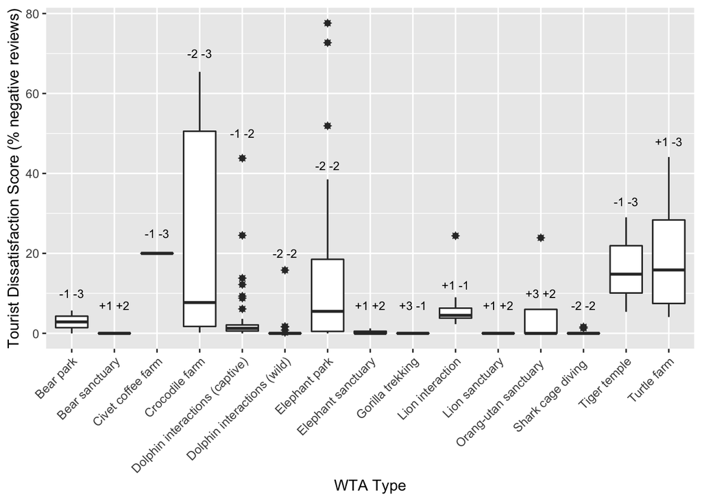

```r
> q<- qplot(Type,Percentage, data=WTA_reviews, geom="boxplot", xlab= "WTA Type", ylab = "Tourist Dissatisfaction Score (% negative reviews)")
> q<- q + theme(axis.text.x = element_text(angle = 45, vjust = 1, hjust=1)) #putting the x labels on an angle
> q<- q + geom_boxplot(outlier.shape = 8) #changing the shape of the outlier points to asterisks
> q<- q + annotate("text", x = 1, y = 10, label = "-1 -3", size=3) #I'm using annotate() to manually add in the conservation and welfare scores onto the plot, probably not the most efficient way since I have to do it for every single WTA type alone the x-axis
> q<- q + annotate("text", x = 2, y = 7, label = "+1 +2", size=3)
> q<- q + annotate("text", x = 3, y = 25, label = "-1 -3", size=3)
> q<- q + annotate("text", x = 4, y = 70, label = "-2 -3", size=3)
> q<- q + annotate("text", x = 5, y = 50, label = "-1 -2", size=3)
> q<- q + annotate("text", x = 6, y = 20, label = "-2 -2", size=3)
> q<- q + annotate("text", x = 7, y = 42, label = "-2 -2", size=3)
> q<- q + annotate("text", x = 8, y = 7, label = "+1 +2", size=3)
> q<- q + annotate("text", x = 9, y = 7, label = "+3 -1", size=3)
> q<- q + annotate("text", x = 10, y = 12, label = "+1 -1", size=3)
> q<- q + annotate("text", x = 11, y = 7, label = "+1 +2", size=3)
> q<- q + annotate("text", x = 12, y = 10, label = "+3 +2", size=3)
> q<- q + annotate("text", x = 13, y = 7, label = "-2 -2", size=3)
> q<- q + annotate("text", x = 14, y = 33, label = "-1 -3", size=3)
> q<- q + annotate("text", x = 15, y = 48, label = "+1 -3", size=3)
> q
```

Figure 3. **Tourist dissatisfaction scores from TripAdvisor reviews (measured as the percentage of all positive and negative reviews that were negative)**. Bars represent the median, boxes the interquartile range, and asterisks outlying points. Numbers above each column, for reference, show the independently awarded conservation and welfare scores, respectively, for each attraction.

#### **Image from Published Paper**

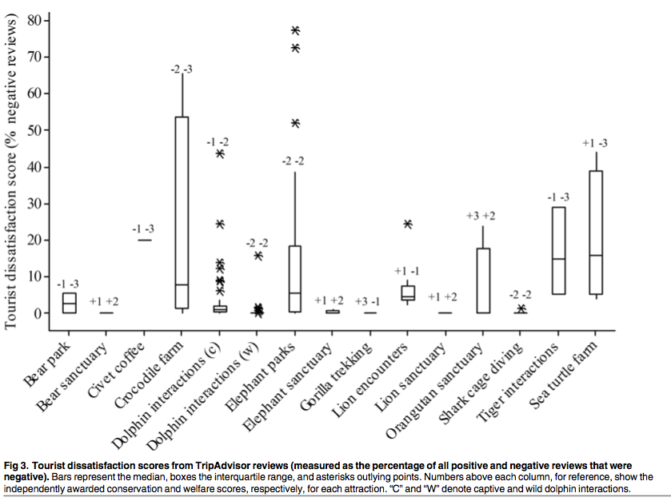

### Conclusion

This paper addresses the conservation and welfare impacts of a variety of non-consumptive, non-zoo wildlife tourist attractions located around the world. Overall, they concluded from a subset of 24 attractions that the majority of WTAs have negative impacts on the subject taxaon’s conservation status as well as negative impacts on their welfare. They found an inverse relationship between mean tourist dissatisfaction score and the welfare scores. However, they concluded that the majority of tourists will not recognize and acknowledge poor animal welfare when visiting these WTAs (80% of tourists).

These authors recommend an urgent need for WTA accreditation or certification processes, as well as periodic inspections, to enhance regulations globally. They also recommend improved tourist education through travel guides and online consumer reviews on platforms such as TripAdvisor. Therefore, tourists against institutions with negative welfare and conservation impacts will be properly informed prior to visiting.